# Упражнение № 6

Спиридонова Алина

25 03 2021

## Вариант № 24 (6)

1. Примените указанные в варианте метод к набору данных по своему варианту (см. таблицу ниже). Не забудьте предварительно сделать из категориальных переменных факторы. Выберите оптимальную модель с помощью кросс-валидации. Выведите её коэффициенты с помощью функции coef(). Рассчитайте MSE модели на тестовой выборке.
2. Примените указанные в варианте метод к набору данных по своему варианту (см. таблицу ниже). Для модели:
- Подогнать модель на всей выборке и вычислить ошибку (MSE) с кросс-валидацией. По наименьшей MSE подобрать оптимальное значение настроечного параметра метода (гиперпараметр λ или число главных компонент M). - Подогнать модель с оптимальным значением параметра на обучающей выборке, посчитать MSE на тестовой.
- Подогнать модель с оптимальным значением параметра на всех данных, вывести характеристики модели функцией summary().
3. Сравните оптимальные модели, полученные в заданиях 1 и 2 по MSE на тестовой выборке. Какой метод дал лучший результат? Доля тестовой выборки: 50%.

## Регуляризация линейных моделей

Модели: линейная регрессия, ридж, лассо, PCR, PLS.

Данные: *AUTO {ISLR}*

Набор данных по автомобилям *Auto*.

```r
my.seed <- 24
#?Auto
Auto <- subset(Auto, select = c(mpg, cylinders, displacement, horsepower, weight, acceleration, year, origin))

Auto$cylinders <- as.factor(Auto$cylinders)
Auto$origin <- as.factor(Auto$origin)
```

```r
names(Auto)
```

```
## [1] "mpg"          "cylinders"    "displacement" "horsepower"   "weight"
## [6] "acceleration" "year"         "origin"
```

```r
dim(Auto)
```

```
## [1] 392   8
```

```r
str(Auto)
```

```
## 'data.frame':    392 obs. of  8 variables:
##  $ mpg         : num  18 15 18 16 17 15 14 14 14 15 ...
##  $ cylinders   : Factor w/ 5 levels "3","4","5","6",..: 5 5 5 5 5 5 5 5 5 5 ...
##  $ displacement: num  307 350 318 304 302 429 454 440 455 390 ...
##  $ horsepower  : num  130 165 150 150 140 198 220 215 225 190 ...
##  $ weight      : num  3504 3693 3436 3433 3449 ...
##  $ acceleration: num  12 11.5 11 12 10.5 10 9 8.5 10 8.5 ...
##  $ year        : num  70 70 70 70 70 70 70 70 70 70 ...
##  $ origin      : Factor w/ 3 levels "1","2","3": 1 1 1 1 1 1 1 1 1 1 ...
```

Считаем число пропусков в зависимой переменной и убираем их.

```r
# считаем пропуски
sum(is.na(Auto$mpg))
```

```
## [1] 0
```

## Задание 1

# Отбор путём пошагового исключения переменных

```r
regfit.full <- regsubsets(Salary ~ ., Hitters, nvmax = 11)
reg.summary <- summary(regfit.full)
reg.summary
```

```
## Subset selection object
## Call: regsubsets.formula(Salary ~ ., Hitters, nvmax = 11)
## 19 Variables  (and intercept)
##            Forced in Forced out
## AtBat          FALSE      FALSE
## Hits           FALSE      FALSE
## HmRun          FALSE      FALSE
## Runs           FALSE      FALSE
## RBI            FALSE      FALSE
## Walks          FALSE      FALSE
## Years          FALSE      FALSE
## CAtBat         FALSE      FALSE
## CHits          FALSE      FALSE
## CHmRun         FALSE      FALSE
## CRuns          FALSE      FALSE
## CRBI           FALSE      FALSE
## CWalks         FALSE      FALSE
## LeagueN        FALSE      FALSE
## DivisionW      FALSE      FALSE
## PutOuts        FALSE      FALSE
## Assists        FALSE      FALSE
## Errors         FALSE      FALSE
## NewLeagueN     FALSE      FALSE
## 1 subsets of each size up to 11
## Selection Algorithm: exhaustive
##           AtBat Hits HmRun Runs RBI Walks Years CAtBat CHits CHmRun CRuns CRBI
## 1  ( 1 )  " "   " "  " "   " "  " " " "   " "   " "    " "   " "    " "   "*"
## 2  ( 1 )  " "   "*"  " "   " "  " " " "   " "   " "    " "   " "    " "   "*"
## 3  ( 1 )  " "   "*"  " "   " "  " " " "   " "   " "    " "   " "    " "   "*"
## 4  ( 1 )  " "   "*"  " "   " "  " " " "   " "   " "    " "   " "    " "   "*"
## 5  ( 1 )  "*"   "*"  " "   " "  " " " "   " "   " "    " "   " "    " "   "*"
## 6  ( 1 )  "*"   "*"  " "   " "  " " "*"   " "   " "    " "   " "    " "   "*"
## 7  ( 1 )  " "   "*"  " "   " "  " " "*"   " "   "*"    "*"   "*"    " "   " "
## 8  ( 1 )  "*"   "*"  " "   " "  " " "*"   " "   " "    " "   "*"    "*"   " "
## 9  ( 1 )  "*"   "*"  " "   " "  " " "*"   " "   "*"    " "   " "    "*"   "*"
## 10  ( 1 ) "*"   "*"  " "   " "  " " "*"   " "   "*"    " "   " "    "*"   "*"
## 11  ( 1 ) "*"   "*"  " "   " "  " " "*"   " "   "*"    " "   " "    "*"   "*"
##           CWalks LeagueN DivisionW PutOuts Assists Errors NewLeagueN
## 1  ( 1 )  " "    " "     " "       " "     " "     " "    " "
## 2  ( 1 )  " "    " "     " "       " "     " "     " "    " "
## 3  ( 1 )  " "    " "     " "       "*"     " "     " "    " "
## 4  ( 1 )  " "    " "     "*"       "*"     " "     " "    " "
## 5  ( 1 )  " "    " "     "*"       "*"     " "     " "    " "
## 6  ( 1 )  " "    " "     "*"       "*"     " "     " "    " "
## 7  ( 1 )  " "    " "     "*"       "*"     " "     " "    " "
## 8  ( 1 )  "*"    " "     "*"       "*"     " "     " "    " "
## 9  ( 1 )  "*"    " "     "*"       "*"     " "     " "    " "
## 10  ( 1 ) "*"    " "     "*"       "*"     "*"     " "    " "
## 11  ( 1 ) "*"    "*"     "*"       "*"     "*"     " "    " "
```

```r
regfit.bwd <- regsubsets(mpg ~ ., data = Auto,
                         nvmax = 11, method = 'backward')
summary(regfit.bwd)
```

```
## Subset selection object
## Call: regsubsets.formula(mpg ~ ., data = Auto, nvmax = 11, method = "backward")
## 11 Variables  (and intercept)
##              Forced in Forced out
## cylinders4       FALSE      FALSE
## cylinders5       FALSE      FALSE
## cylinders6       FALSE      FALSE
## cylinders8       FALSE      FALSE
## displacement     FALSE      FALSE
## horsepower       FALSE      FALSE
## weight           FALSE      FALSE
## acceleration     FALSE      FALSE
## year             FALSE      FALSE
## origin2          FALSE      FALSE
## origin3          FALSE      FALSE
## 1 subsets of each size up to 11
## Selection Algorithm: backward
##           cylinders4 cylinders5 cylinders6 cylinders8 displacement horsepower
## 1  ( 1 )  " "        " "        " "        " "        " "          " "
## 2  ( 1 )  " "        " "        " "        " "        " "          " "
## 3  ( 1 )  "*"        " "        " "        " "        " "          " "
## 4  ( 1 )  "*"        " "        " "        " "        " "          " "
## 5  ( 1 )  "*"        " "        " "        " "        " "          " "
## 6  ( 1 )  "*"        " "        " "        " "        "*"          " "
## 7  ( 1 )  "*"        " "        " "        " "        "*"          "*"
## 8  ( 1 )  "*"        "*"        " "        " "        "*"          "*"
## 9  ( 1 )  "*"        "*"        " "        "*"        "*"          "*"
## 10  ( 1 ) "*"        "*"        "*"        "*"        "*"          "*"
## 11  ( 1 ) "*"        "*"        "*"        "*"        "*"          "*"
##           weight acceleration year origin2 origin3
## 1  ( 1 )  "*"    " "          " "  " "     " "
## 2  ( 1 )  "*"    " "          "*"  " "     " "
## 3  ( 1 )  "*"    " "          "*"  " "     " "
## 4  ( 1 )  "*"    " "          "*"  " "     "*"
## 5  ( 1 )  "*"    " "          "*"  "*"     "*"
## 6  ( 1 )  "*"    " "          "*"  "*"     "*"
## 7  ( 1 )  "*"    " "          "*"  "*"     "*"
## 8  ( 1 )  "*"    " "          "*"  "*"     "*"
## 9  ( 1 )  "*"    " "          "*"  "*"     "*"
## 10  ( 1 ) "*"    " "          "*"  "*"     "*"
## 11  ( 1 ) "*"    "*"          "*"  "*"     "*"
```

```r
round(coef(regfit.bwd, 7), 3)
```

```
##  (Intercept)   cylinders4 displacement   horsepower       weight         year
##      -21.362        4.019        0.029       -0.039       -0.006        0.751
##      origin2      origin3
##        2.213        2.803
```

k-кратная кросс-валидация

```r
# функция для прогноза для функции regsubset()
predict.regsubsets <- function(object, newdata, id, ...){
    form <- as.formula(object$call[[2]])
    mat <- model.matrix(form, newdata)
    coefi <- coef(object, id = id)
    xvars <- names(coefi)
    mat[, xvars] %*% coefi
}




# отбираем 10 блоков наблюдений
k <- 10
set.seed(my.seed)
folds <- sample(1:k, nrow(Auto), replace = T)

# заготовка под матрицу с ошибками
cv.errors <- matrix(NA, k, 11, dimnames = list(NULL, paste(1:11)))

# заполняем матрицу в цикле по блокам данных
for (j in 1:k){
    best.fit <- regsubsets(mpg ~ ., data = Auto[folds != j, ],
                           nvmax = 11)
    # теперь цикл по количеству объясняющих переменных
    for (i in 1:11){
        # модельные значения Salary
        pred <- predict(best.fit,Auto[folds == j, ], id = i)
        # вписываем ошибку в матрицу
        cv.errors[j, i] <- mean((Auto$mpg[folds == j] - pred)^2)
    }
}

# усредняем матрицу по каждому столбцу (т.е. по блокам наблюдений),
#  чтобы получить оценку MSE для каждой модели с фиксированным
#  количеством объясняющих переменных
mean.cv.errors <- apply(cv.errors, 2, mean)
round(mean.cv.errors, 0)
```

```
##  1  2  3  4  5  6  7  8  9 10 11
## 18 12 11 11 11 11 10 10 10 10 10
```

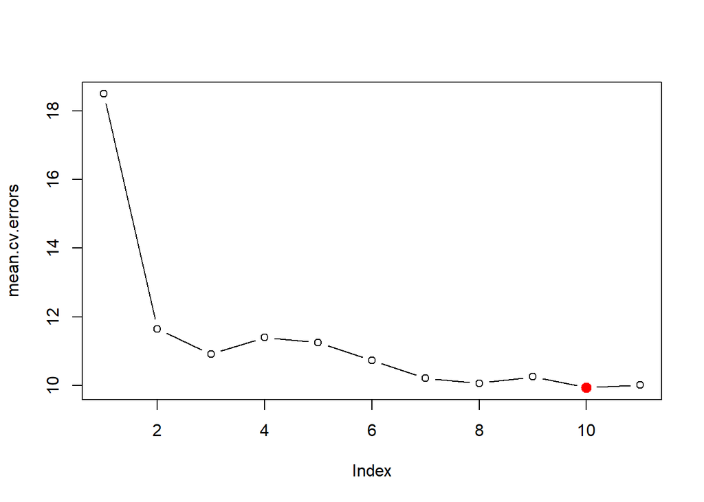

```r
# на графике
plot(mean.cv.errors, type = 'b')
points(which.min(mean.cv.errors), mean.cv.errors[which.min(mean.cv.errors)],
       col = 'red', pch = 20, cex = 2)
```

```r
reg.best <- regsubsets(mpg ~ ., data = Auto, nvmax = 10)
round(coef(reg.best, 10), 3)
```

```
##  (Intercept)   cylinders4   cylinders5   cylinders6   cylinders8 displacement
##      -21.623        6.784        7.147        3.403        5.137        0.018
##   horsepower       weight         year      origin2      origin3
##       -0.037       -0.006        0.736        1.763        2.621
```

Расчет MSE по тестовой выборке

```r
DF.auto <- Auto

# общее число наблюдений
n <- nrow(DF.auto)

# доля обучающей выборки
train.percent <- 0.5

# выбрать наблюдения в обучающую выборку
set.seed(my.seed)
inTrain <- sample(1:n, n * train.percent)

# фактические значения Y на тестовой выборке
y.test.fact <- DF.auto$mpg[-inTrain]

# присоединить таблицу с данными: названия стоблцов будут доступны напрямую
attach(DF.auto)

# подгонка модели на обучающей выборке
fit.lm <- lm(mpg ~ . , subset = inTrain,  data = Auto)

# подгонка линейной модели на обучающей выборке
fit.lm <- lm(mpg ~ . ,
               subset = inTrain,  data = Auto)

#объединение уровней переменной cylinders
fit.lm$xlevels[['cylinders']] <- union(fit.lm$xlevels[['cylinders']], levels(DF.auto$cylinders))
# прогноз на тестовую
y.test.lm <- predict(fit.lm, DF.auto[-inTrain, ])
# считаем MSE на тестовой выборке
MSE.lm <- mean((y.test.fact - y.test.lm)^2)

# отсоединить таблицу с данными
detach(DF.auto)

# смотрим ошибку
MSE.lm
```

[output not shown]